# Homework6

BMV

2/20/2018

```r
#Load libraries
library(ggplot2) # for graphics
library(MASS) # for maximum likelihood estimation
```

The example code is not printed in the output, but it is here for reference.

- So you can eyeball the shape fit/ or do goodness of fit test, what next? What do you actually do with the distribution that best fits the data?

Now to use my own data:

The data I have are census data for forest tree species. The data include 9 census years and spans an elevational gradient. There are 10 stands spaced evenly across the slope, and each stand has 10 or 5 plots. Within each plot, the species and diameter-at-breast height were recorded for each species (> 2 cm minimum).

I am going to subset the data for a particular species, red spruce (coded here as 4). I would like to see the distribution of DBH. I will start by subsetting the data for this species and for one year (1 plot). Ultimately, I would like to do this for all 9 years ( 9 plots). I could even subset further to look at distribution of dbh for each stand across all 9 census years (90 plots).

There is a magnitude difference in the number of obs. I wonder if 197 obs are enough.

```r
data=read.csv("/Volumes/Macintosh HD/Users/Brittany/Documents/UVM/red spruce/CHSurvey1965_2015/CH_data_1965_2015.csv", header=TRUE)

picea=subset(data, data$SPECIES==4)
# 1211 obs.
picea_65=subset(picea, picea$YR==1965)
# 197 obs.
summary(picea_65$DIAM)
```

```
##    Min. 1st Qu.  Median    Mean 3rd Qu.    Max.
##   2.000   3.300   4.800   9.855  10.400  56.600
```

```r
# the data are bounded at a lower limit of 2cm diameter. I wonder how this translates to the bound of 0. Does this act as my 0?
```

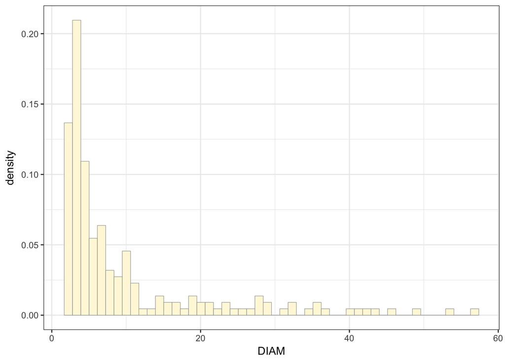

```r
p1 <- ggplot(data=picea_65, aes(x=DIAM, y=..density..)) +
  geom_histogram(color="grey60",fill="cornsilk",size=0.2, bins = 50) +
  theme_bw()
print(p1)
```

Add a denisty curve based on the data.

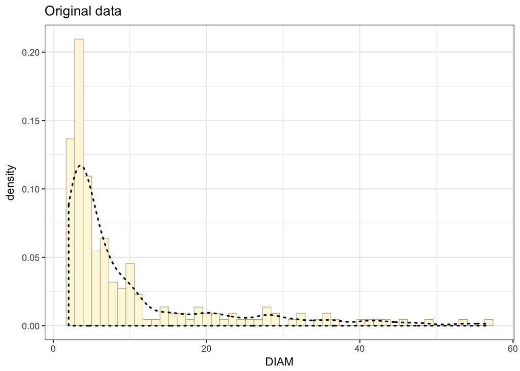

```r
p1 <-  p1 +  geom_density(linetype="dotted",size=0.75) +ggtitle("Original data")
print(p1)
```

Use the `normal` distribution to find max. likelihood estimates of the mean and standard deviation.

```r
normPars <- fitdistr(picea_65$DIAM,"normal")
print(normPars) # large sd
```

```
##       mean          sd
##    9.8548223   11.0182562
##  ( 0.7850182) ( 0.5550917)
```

```r
str(normPars)
```

```
## List of 5
##  $ estimate: Named num [1:2] 9.85 11.02
##   ..- attr(*, "names")= chr [1:2] "mean" "sd"
##  $ sd      : Named num [1:2] 0.785 0.555
##   ..- attr(*, "names")= chr [1:2] "mean" "sd"
##  $ vcov    : num [1:2, 1:2] 0.616 0 0 0.308
##   ..- attr(*, "dimnames")=List of 2
##   .. ..$ : chr [1:2] "mean" "sd"
##   .. ..$ : chr [1:2] "mean" "sd"
##  $ n       : int 197
##  $ loglik  : num -752
##  - attr(*, "class")= chr "fitdistr"
```

Plot the `normal` probability density function. My gut says this will not fit the data very well.

```r
# Assign the max. like. estimates of mean and sd to objects to be passed to model.
meanML <- normPars$estimate["mean"]
sdML <- normPars$estimate["sd"]

xval <- seq(0,max(picea_65$DIAM),len=length(picea_65$DIAM))
# correct number of obs. in xval. but why is this needed? why not use DIAM values?

 stat <- stat_function(aes(x = xval, y = ..y..), fun = dnorm, colour="red", n = length(picea_65$myVar), args = list(mean = meanML, sd = sdML))
 p1 + stat
```

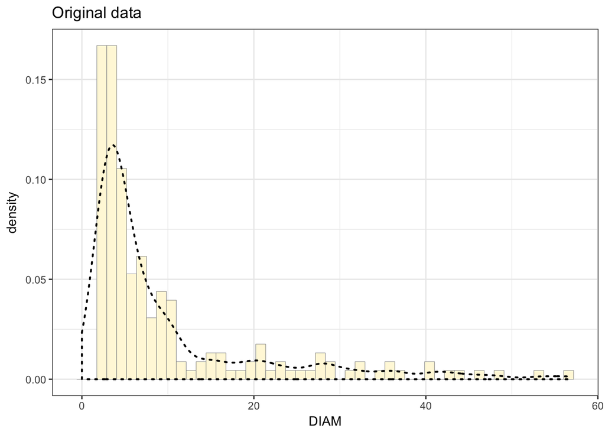

Plot `exponential` probability density. This may look okay. Not as good as what I was expecting, but still not too bad.

```r
# Get the needed rate parm to fit the distribution.
expoPars <- fitdistr(picea_65$DIAM,"exponential")
rateML <- expoPars$estimate["rate"]

stat2 <- stat_function(aes(x = xval, y = ..y..), fun = dexp, colour="blue", n = length(picea_65), args = list(rate=rateML))
 p1 + stat + stat2
```

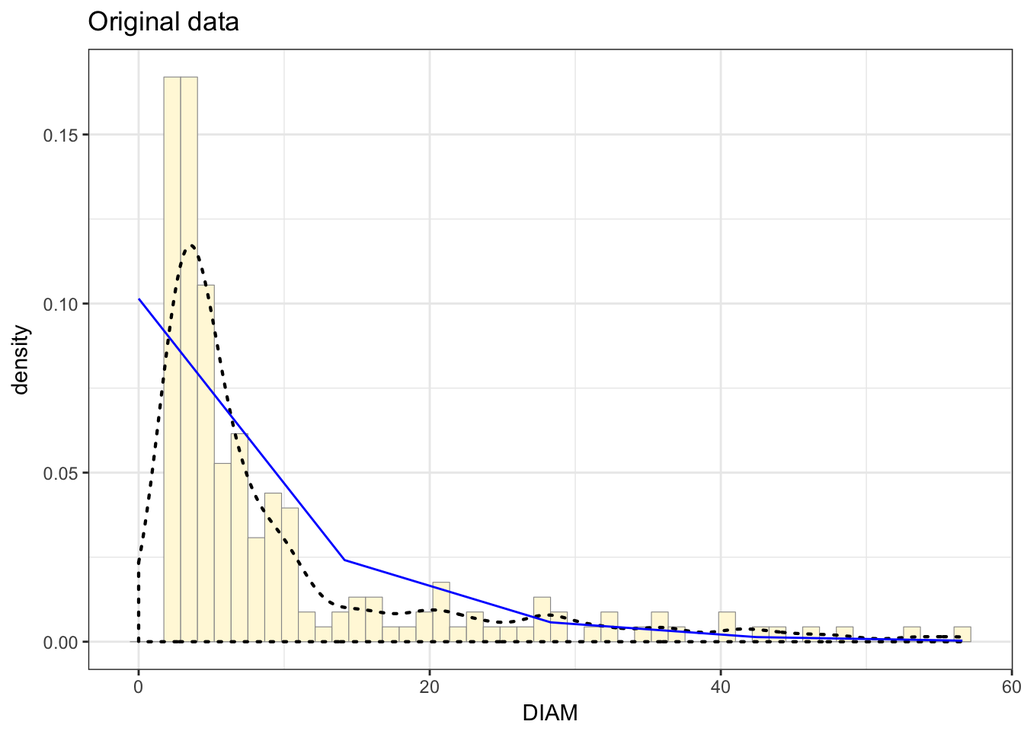

Plot `uniform` probability density. Should look terrible.

```r
# remember, the min and max of picea_65$DIAM are the data that go into this function.
stat3 <- stat_function(aes(x = xval, y = ..y..), fun = dunif, colour="darkgreen", n = length(picea_65$DIAM), args = list(min=min(picea_65$DIAM), max=max(picea_65$DIAM)))
 p1 + stat + stat2 + stat3
```

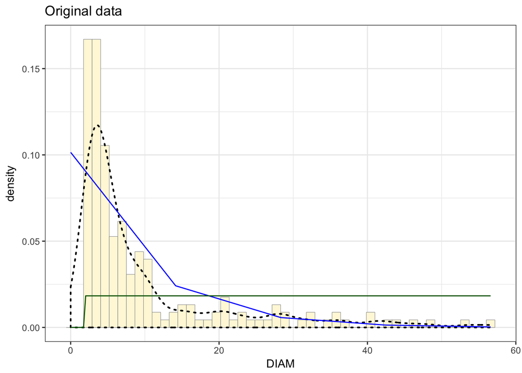

I am noticing that all my distributions start at 0, even though I do not have data at 0cm diameter. Also, none of the distributions seems to capture the high density of small diameters.

Plot `gamma` probability density.

```r
gammaPars <- fitdistr(picea_65$DIAM,"gamma")
shapeML <- gammaPars$estimate["shape"]
rateML <- gammaPars$estimate["rate"]

stat4 <- stat_function(aes(x = xval, y = ..y..), fun = dgamma, colour="indianred", n = length(picea_65$DIAM), args = list(shape=shapeML, rate=rateML))
 p1 + stat + stat2 + stat3 + stat4
```

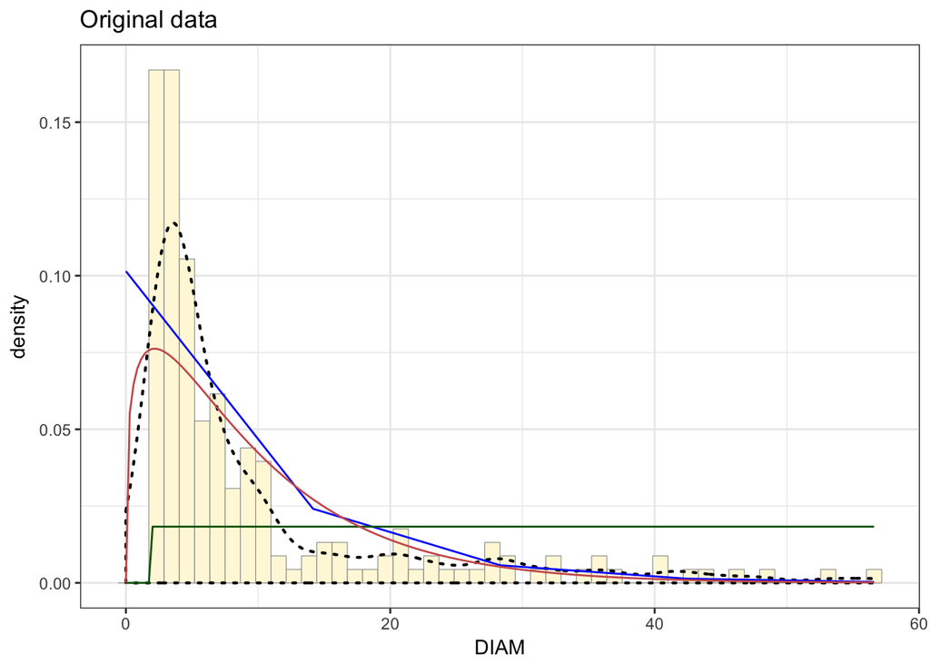

Adding in more distributions to see if any others will capture more of the density with smaller dimeters.

Plot the `weibull` probability distribution

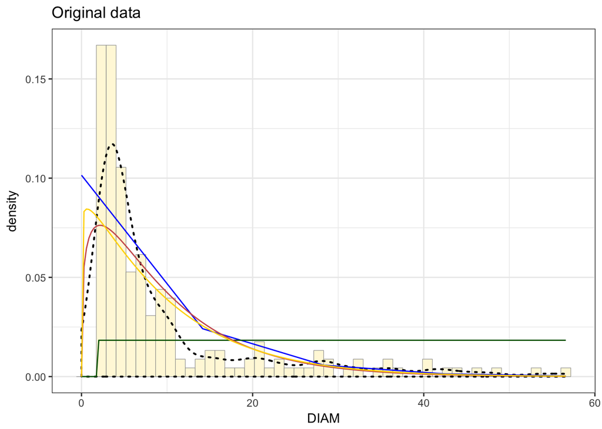

```r
weibullPars <- fitdistr(picea_65$DIAM,"weibull")
shapeML <- weibullPars$estimate["shape"]
scaleML <- weibullPars$estimate["scale"]

stat5 <- stat_function(aes(x = xval, y = ..y..), fun = dweibull, colour="gold", n = length(picea_65$DIAM), args = list(shape=shapeML, scale=scaleML))
p1 + stat + stat2 + stat3 + stat4 + stat5
```

Plot `log normal` probability distribution.

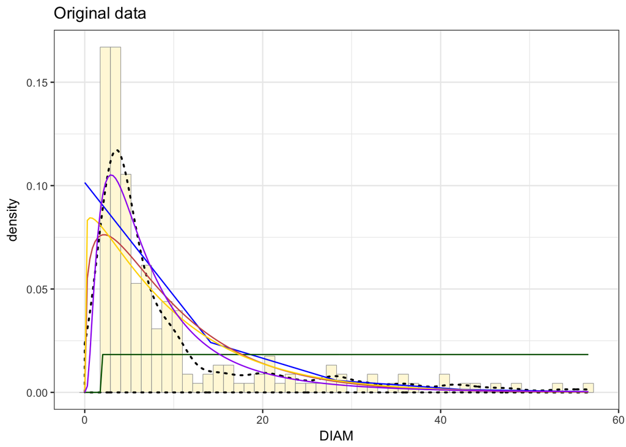

```r
lognormPars <- fitdistr(picea_65$DIAM,"lognormal")

# Assign the max. like. estimates of mean and sd to objects to be passed to model.
logmeanML <- lognormPars$estimate["meanlog"]
logsdML <- lognormPars$estimate["sdlog"]

stat6 <- stat_function(aes(x = xval, y = ..y..), fun = dlnorm, colour="purple", n = length(picea_65$DIAM), args = list(mean = logmeanML, sd = logsdML))

p1 + stat + stat2 + stat3 + stat4 + stat5 + stat6
```

Plot the `logistic` probability distribution

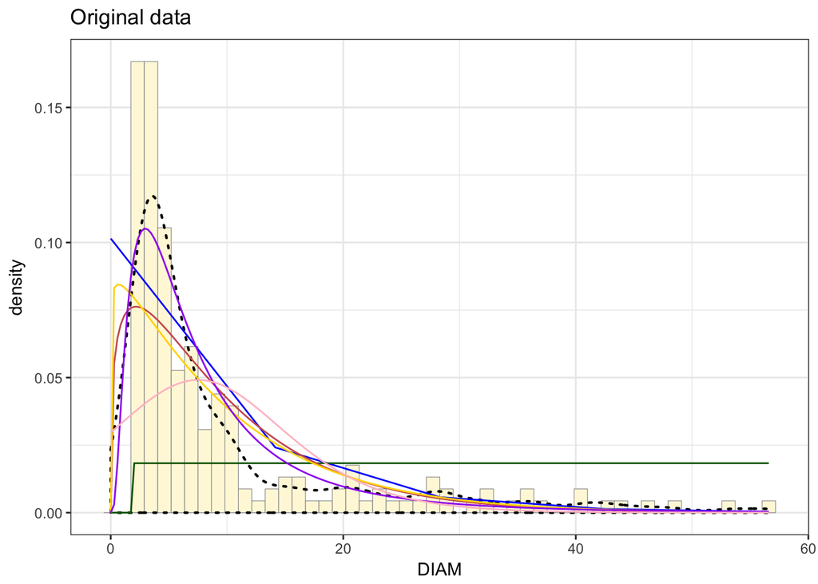

```r
logPars <- fitdistr(picea_65$DIAM,"logistic")
loglocationML <- logPars$estimate["location"]
logscaleML <- logPars$estimate["scale"]

stat7 <- stat_function(aes(x = xval, y = ..y..), fun = dlogis, colour="pink", n = length(picea_65$DIAM), args = list(location=loglocationML, scale=logscaleML))

p1 + stat + stat2 + stat3 + stat4 + stat5 +stat6 +stat7
```

Plot `beta` probability density. Remember to scale between 0-1– needs to be a separate figure because of this.

Captures the high density of small diameteres, but still looks a bit off.

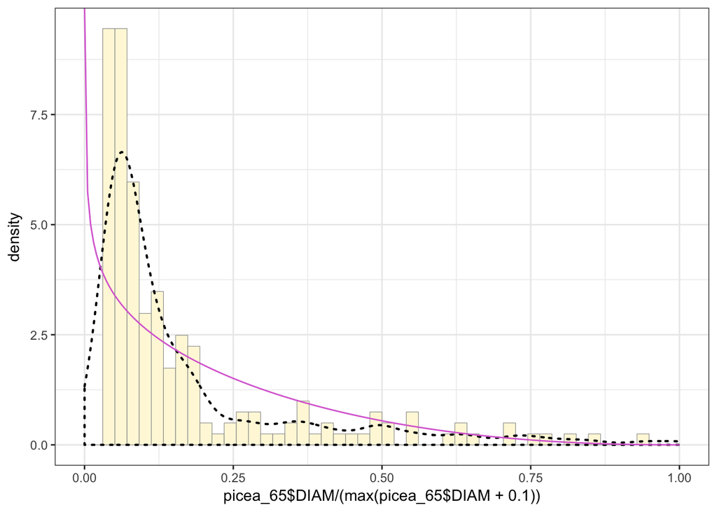

```r
pSpecial <- ggplot(data=picea_65, aes(x=picea_65$DIAM/(max(picea_65$DIAM + 0.1)), y=..density..)) +
  geom_histogram(color="grey60",fill="cornsilk",size=0.2, bins = 50) +
  xlim(c(0,1)) +
  geom_density(size=0.75,linetype="dotted") + theme_bw()

betaPars <- fitdistr(x=picea_65$DIAM/max(picea_65$DIAM + 0.1),start=list(shape1=1,shape2=2),"beta")
shape1ML <- betaPars$estimate["shape1"]
shape2ML <- betaPars$estimate["shape2"]


statSpecial <- stat_function(aes(x = xval, y = ..y..), fun = dbeta, colour="orchid", n = length(picea_65$DIAM), args = list(shape1=shape1ML,shape2=shape2ML))

pSpecial + statSpecial
```

Look at the stats to see which model is best.

Compare log likelihoods: the highest number is the best.

**Log normal is the best fitting distribution.**

```r
normPars$loglik
```

```
## [1] -752.2429
```

```r
logPars$loglik
```

```
## [1] -729.4882
```

```r
gammaPars$loglik
```

```
## [1] -644.2241
```

```r
expoPars$loglik
```

```
## [1] -647.7283
```

```r
lognormPars$loglik
```

```
## [1] -617.3823
```

```r
weibullPars$loglik
```

```
## [1] -647.1416
```

Look at AIC values. Smaller values are better.

**Log normal still pulling as best distribution.**

```r
library(fitdistrplus)
fit.norm=fitdist(picea_65$DIAM, "norm")
fit.norm$aic
```

```
## [1] 1508.486
```

```r
fit.logistic=fitdist(picea_65$DIAM, "logis")
fit.logistic$aic
```

```
## [1] 1462.976
```

```r
fit.gamma=fitdist(picea_65$DIAM, "gamma")
fit.gamma$aic
```

```
## [1] 1292.448
```

```r
fit.expo=fitdist(picea_65$DIAM, "exp")
fit.expo$aic
```

```
## [1] 1297.457
```

```r
fit.lognorm=fitdist(picea_65$DIAM, "lnorm")
fit.lognorm$aic
```

```
## [1] 1238.765
```

```r
fit.weibull=fitdist(picea_65$DIAM, "weibull")
fit.weibull$aic
```

```
## [1] 1298.283
```

**Simulate data using the maximum likelihood estimates from the `log normal` distribution.**

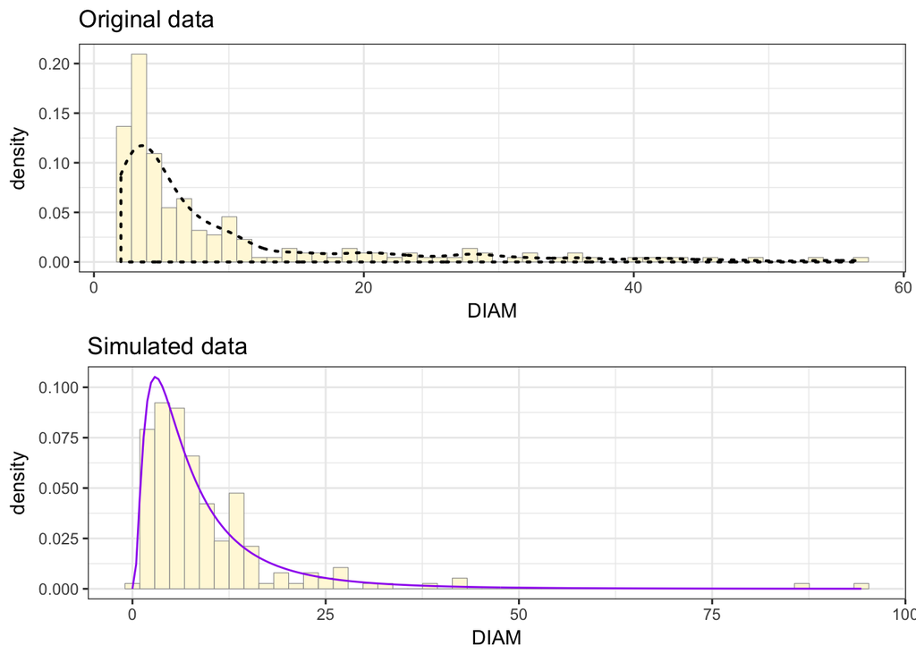

```r
logmeanML <- lognormPars$estimate["meanlog"]
logsdML <- lognormPars$estimate["sdlog"]

# Use 197 for n because this is what i have in the og data
sim_data=rlnorm(n=197, meanlog=logmeanML, sd=logsdML)
sim_data <- data.frame(1:197,sim_data)
colnames(sim_data)=c("x", "DIAM")
# plot a basic histogram and add the probability density curve.
p_sim_data <- ggplot(data=sim_data, aes(x=DIAM, y=..density..)) +
  geom_histogram(color="grey60",fill="cornsilk",size=0.2, bins = 50) +
  theme_bw()

p_sim_data <-  p_sim_data +  stat6 + ggtitle("Simulated data")

# Add in original data to compare

library(gridExtra)
grid.arrange(p1, p_sim_data, nrow=2)
```

Look at the distribution of spruce across the years.

```r
picea_79=subset(picea, picea$YR==1979)
picea_83=subset(picea, picea$YR==1983)
picea_86=subset(picea, picea$YR==1986)
picea_90=subset(picea, picea$YR==1990)
picea_95=subset(picea, picea$YR==1995)
picea_00=subset(picea, picea$YR==2000)
picea_04=subset(picea, picea$YR==2004)
picea_15=subset(picea, picea$YR==2015)
```

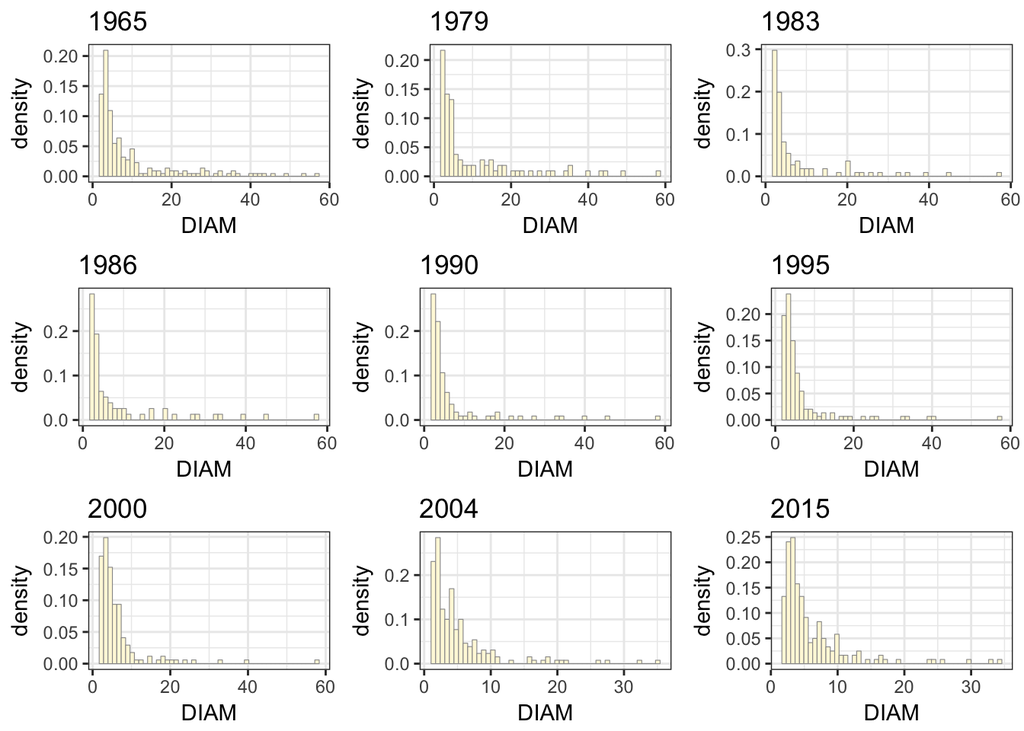

```r
p65 <- ggplot(data=picea_65, aes(x=DIAM, y=..density..)) +
  geom_histogram(color="grey60",fill="cornsilk",size=0.2, bins = 50) +
  theme_bw() + ggtitle("1965")

p79 <- ggplot(data=picea_79, aes(x=DIAM, y=..density..)) +
  geom_histogram(color="grey60",fill="cornsilk",size=0.2, bins = 50) +
  theme_bw()+ ggtitle("1979")

p83 <- ggplot(data=picea_83, aes(x=DIAM, y=..density..)) +
  geom_histogram(color="grey60",fill="cornsilk",size=0.2, bins = 50) +
  theme_bw()+ ggtitle("1983")

p86 <- ggplot(data=picea_86, aes(x=DIAM, y=..density..)) +
  geom_histogram(color="grey60",fill="cornsilk",size=0.2, bins = 50) +
  theme_bw()+ ggtitle("1986")

p90 <- ggplot(data=picea_90, aes(x=DIAM, y=..density..)) +
  geom_histogram(color="grey60",fill="cornsilk",size=0.2, bins = 50) +
  theme_bw()+ ggtitle("1990")

p95 <- ggplot(data=picea_95, aes(x=DIAM, y=..density..)) +
  geom_histogram(color="grey60",fill="cornsilk",size=0.2, bins = 50) +
  theme_bw()+ ggtitle("1995")

p00 <- ggplot(data=picea_00, aes(x=DIAM, y=..density..)) +
  geom_histogram(color="grey60",fill="cornsilk",size=0.2, bins = 50) +
  theme_bw()+ ggtitle("2000")

p04 <- ggplot(data=picea_04, aes(x=DIAM, y=..density..)) +
  geom_histogram(color="grey60",fill="cornsilk",size=0.2, bins = 50) +
  theme_bw() + ggtitle("2004")

p15 <- ggplot(data=picea_15, aes(x=DIAM, y=..density..)) +
  geom_histogram(color="grey60",fill="cornsilk",size=0.2, bins = 50) +
  theme_bw() + ggtitle("2015")

library(gridExtra)
grid.arrange(p65, p79, p83, p86, p90, p95, p00, p04, p15, nrow = 3, ncol=3)
```

While the data in different years may be modeled best by different distributions, I am going to apply the log normal distribution to each year.

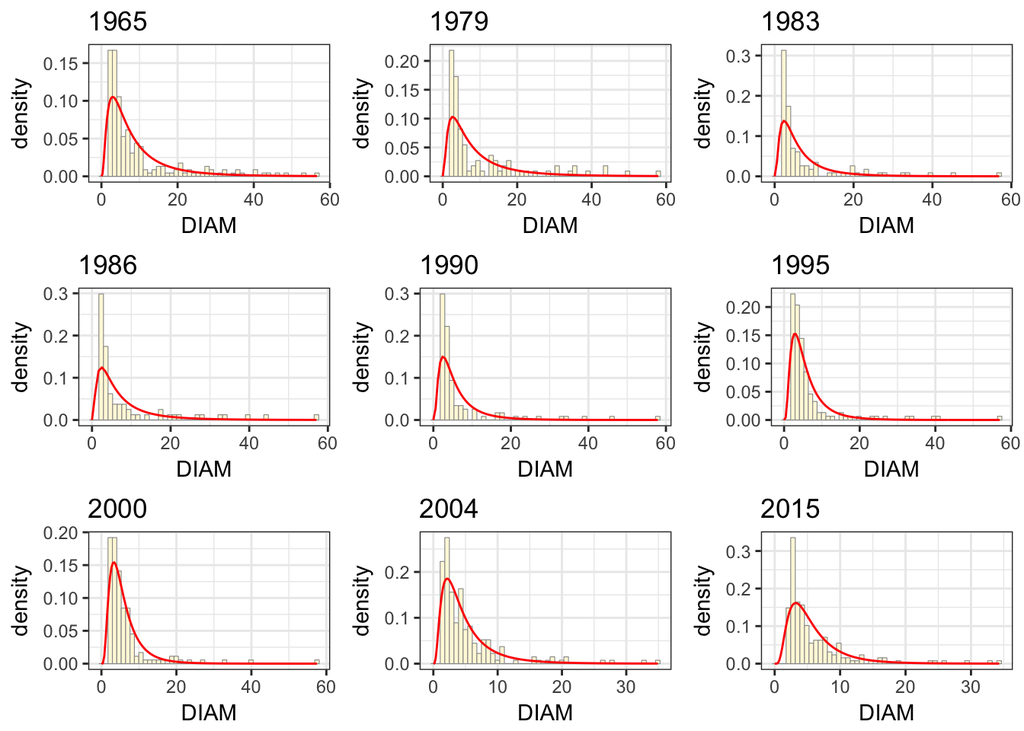

```r
parms65 <- fitdistr(picea_65$DIAM,"lognormal")
parms79 <- fitdistr(picea_79$DIAM,"lognormal")
parms83 <- fitdistr(picea_83$DIAM,"lognormal")
parms86 <- fitdistr(picea_86$DIAM,"lognormal")
parms90 <- fitdistr(picea_90$DIAM,"lognormal")
parms95 <- fitdistr(picea_95$DIAM,"lognormal")
parms00 <- fitdistr(picea_00$DIAM,"lognormal")
parms04 <- fitdistr(picea_04$DIAM,"lognormal")
parms15 <- fitdistr(picea_15$DIAM,"lognormal")

# Assign the max. like. estimates of mean and sd to objects to be passed to model.
mean65<- parms65$estimate["meanlog"]
sd65 <- parms65$estimate["sdlog"]

mean79<- parms79$estimate["meanlog"]
sd79 <- parms79$estimate["sdlog"]

mean83<- parms83$estimate["meanlog"]
sd83 <- parms83$estimate["sdlog"]

mean86<- parms86$estimate["meanlog"]
sd86 <- parms86$estimate["sdlog"]

mean90<- parms90$estimate["meanlog"]
sd90 <- parms90$estimate["sdlog"]

mean95<- parms95$estimate["meanlog"]
sd95 <- parms95$estimate["sdlog"]

mean00<- parms00$estimate["meanlog"]
sd00 <- parms00$estimate["sdlog"]

mean04<- parms04$estimate["meanlog"]
sd04 <- parms04$estimate["sdlog"]

mean15<- parms15$estimate["meanlog"]
sd15 <- parms15$estimate["sdlog"]

xval65 <- seq(0,max(picea_65$DIAM),len=length(picea_65$DIAM))
xval79 <- seq(0,max(picea_79$DIAM),len=length(picea_79$DIAM))
xval83 <- seq(0,max(picea_83$DIAM),len=length(picea_83$DIAM))
xval86 <- seq(0,max(picea_86$DIAM),len=length(picea_86$DIAM))
xval90 <- seq(0,max(picea_90$DIAM),len=length(picea_90$DIAM))
xval95 <- seq(0,max(picea_95$DIAM),len=length(picea_95$DIAM))
xval00 <- seq(0,max(picea_00$DIAM),len=length(picea_00$DIAM))
xval04 <- seq(0,max(picea_04$DIAM),len=length(picea_04$DIAM))
xval15 <- seq(0,max(picea_15$DIAM),len=length(picea_15$DIAM))

stat65 <- stat_function(aes(x = xval65, y = ..y..), fun = dlnorm, colour="red", n = length(picea_65$DIAM), args = list(mean = mean65, sd = sd65))

stat79 <- stat_function(aes(x = xval79, y = ..y..), fun = dlnorm, colour="red", n = length(picea_79$DIAM), args = list(mean = mean79, sd = sd79))

stat83 <- stat_function(aes(x = xval83, y = ..y..), fun = dlnorm, colour="red", n = length(picea_83$DIAM), args = list(mean = mean83, sd = sd83))

stat86 <- stat_function(aes(x = xval86, y = ..y..), fun = dlnorm, colour="red", n = length(picea_86$DIAM), args = list(mean = mean86, sd = sd86))

stat90 <- stat_function(aes(x = xval90, y = ..y..), fun = dlnorm, colour="red", n = length(picea_90$DIAM), args = list(mean = mean90, sd = sd90))

stat65 <- stat_function(aes(x = xval, y = ..y..), fun = dlnorm, colour="red", n = length(picea_65$DIAM), args = list(mean = mean65, sd = sd65))

stat95 <- stat_function(aes(x = xval95, y = ..y..), fun = dlnorm, colour="red", n = length(picea_95$DIAM), args = list(mean = mean95, sd = sd95))

stat65 <- stat_function(aes(x = xval, y = ..y..), fun = dlnorm, colour="red", n = length(picea_65$DIAM), args = list(mean = mean65, sd = sd65))

stat00 <- stat_function(aes(x = xval00, y = ..y..), fun = dlnorm, colour="red", n = length(picea_00$DIAM), args = list(mean = mean00, sd = sd00))

stat04 <- stat_function(aes(x = xval04, y = ..y..), fun = dlnorm, colour="red", n = length(picea_04$DIAM), args = list(mean = mean04, sd = sd04))

stat15 <- stat_function(aes(x = xval15, y = ..y..), fun = dlnorm, colour="red", n = length(picea_15$DIAM), args = list(mean = mean15, sd = sd15))

p65= p65+ stat65
p79= p79+ stat79
p83= p83+ stat83
p86= p86+ stat86
p90= p90+ stat90
p95= p95+ stat95
p00= p00+ stat00
p04= p04+ stat04
p15= p15+ stat15

grid.arrange(p65, p79, p83, p86, p90, p95, p00, p04, p15, nrow = 3, ncol=3)
```